# Presenting data analysis report in 10 minutes

Mahbubul Majumder, PhD  
Dec 11, 2014

### What to present

- First thing first, present yourself or your team
  - presenting is a privilege not many people have
- Start with a motivational example, something that describes your data
- Describe the problem or the question that you are dealing
- present the data and results
  - not everything is interesting. Just show the **WOW** part
  - use any media, animation, figure or plot that makes it easy to understand
  - 10 minutes is a long time to hold people's interest
- Present your data product if you created one
  - just show what it is good for or why somebody should buy it
- Talk about future direction or planning
- Finally, be excited with your amazing work and let others be excited too

### Talking about your team

- What is interesting about you or your team ?
  - just get the audience ready to enjoy your talk
  - creates a new environment
  - you have only 15-30 seconds to do that
- Interest about yourself can be grown by sharing exciting news
  - for example, give some information like the following while talking about you
    - this project helped you get a job
    - this project motivated you to pursue PhD
    - you forgot to go home one night while working with this project in the lab
    - or whatever

### The first slide

- Spare the first slide to draw attention
  - motivational picture or information related to your work
- Think of the diverse audience you have
  - someone may just got a speeding ticket before getting here
  - someone may be thinking of their talk
  - get all of them on board and forget what they were supposed to think
- Put a **WOW** picture
  - a good picture, with a nice description and your explanation goes a long way

### Motivation example

What types of data you think about when you see this picture?

[figure not shown]

picture source: https://assets3.thrillist.com/v1/image/1304687/size/tmg-slideshow_xxl

### Motivation example

What type of thinking does this plot trigger?

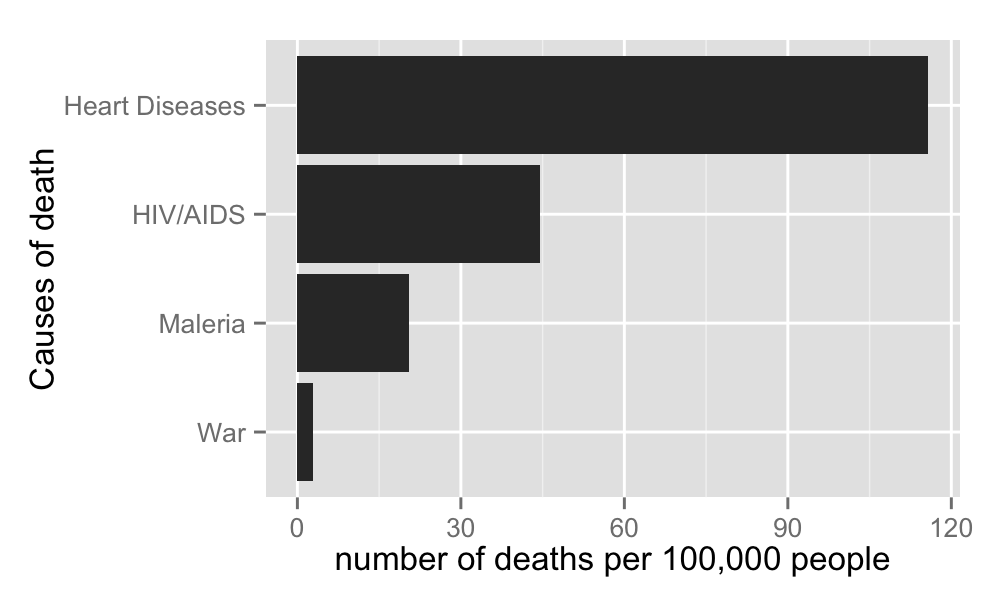

### Good vs bad slides

The definition of a good slide or a bad slide is very simple

# Good means interesting

# Bad means boring

### Example: bad slide

- Suppose you want to talk about statistics. Go ahead with these bullets, you have the power to
  - annoy or irritate the audience
  - or give them a comfort to sleep
- Statistics is the study of the collection, analysis, interpretation, presentation, and organization of data. In applying statistics to, e.g., a scientific, industrial, or societal problem, it is necessary to begin with a population or process to be studied. Populations can be diverse topics such as “all persons living in a country” or “every atom composing a crystal”. It deals with all aspects of data including the planning of data collection in terms of the design of surveys and experiments.
- In case census data cannot be collected, statisticians collect data by developing specific experiment designs and survey samples. Representative sampling assures that inferences and conclusions can safely extend from the sample to the population as a whole. An experimental study involves taking measurements of the system under study, manipulating the system, and then taking additional measurements using the same procedure to determine if the manipulation has modified the values of the measurements. In contrast, an observational study does not involve experimental manipulation.

### Example: bad slide

You don't expect people to read a slide like this in a 10 minute presentation

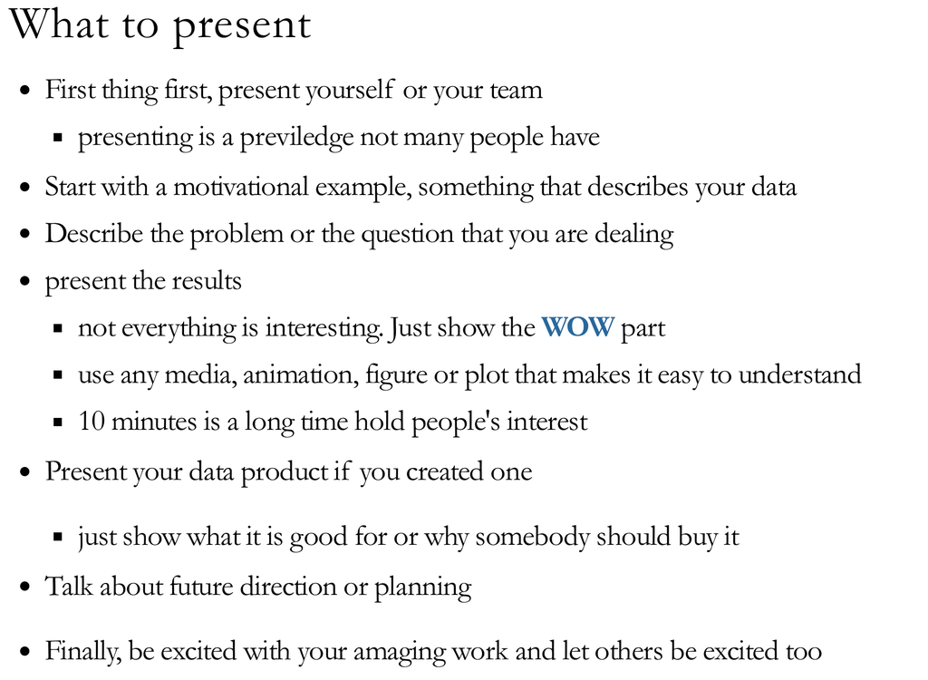

### Example: bad slide

What is the point of showing a table like this?

|  | mpg | cyl | disp | hp | drat | wt | qsec | vs | am | gear | carb |
| --- | --- | --- | --- | --- | --- | --- | --- | --- | --- | --- | --- |
| Mazda RX4 | 21.0 | 6 | 160.0 | 110 | 3.90 | 2.620 | 16.46 | 0 | 1 | 4 | 4 |
| Mazda RX4 Wag | 21.0 | 6 | 160.0 | 110 | 3.90 | 2.875 | 17.02 | 0 | 1 | 4 | 4 |
| Datsun 710 | 22.8 | 4 | 108.0 | 93 | 3.85 | 2.320 | 18.61 | 1 | 1 | 4 | 1 |
| Hornet 4 Drive | 21.4 | 6 | 258.0 | 110 | 3.08 | 3.215 | 19.44 | 1 | 0 | 3 | 1 |
| Hornet Sportabout | 18.7 | 8 | 360.0 | 175 | 3.15 | 3.440 | 17.02 | 0 | 0 | 3 | 2 |
| Valiant | 18.1 | 6 | 225.0 | 105 | 2.76 | 3.460 | 20.22 | 1 | 0 | 3 | 1 |
| Duster 360 | 14.3 | 8 | 360.0 | 245 | 3.21 | 3.570 | 15.84 | 0 | 0 | 3 | 4 |
| Merc 240D | 24.4 | 4 | 146.7 | 62 | 3.69 | 3.190 | 20.00 | 1 | 0 | 4 | 2 |
| Merc 230 | 22.8 | 4 | 140.8 | 95 | 3.92 | 3.150 | 22.90 | 1 | 0 | 4 | 2 |
| Merc 280 | 19.2 | 6 | 167.6 | 123 | 3.92 | 3.440 | 18.30 | 1 | 0 | 4 | 4 |
| Merc 280C | 17.8 | 6 | 167.6 | 123 | 3.92 | 3.440 | 18.90 | 1 | 0 | 4 | 4 |
| Merc 450SE | 16.4 | 8 | 275.8 | 180 | 3.07 | 4.070 | 17.40 | 0 | 0 | 3 | 3 |
| Merc 450SL | 17.3 | 8 | 275.8 | 180 | 3.07 | 3.730 | 17.60 | 0 | 0 | 3 | 3 |
| Merc 450SLC | 15.2 | 8 | 275.8 | 180 | 3.07 | 3.780 | 18.00 | 0 | 0 | 3 | 3 |
| Cadillac Fleetwood | 10.4 | 8 | 472.0 | 205 | 2.93 | 5.250 | 17.98 | 0 | 0 | 3 | 4 |

### Turn a bad slide into good one

- Is it really necessary to show this proof?
  - do you expect the audience to read it?

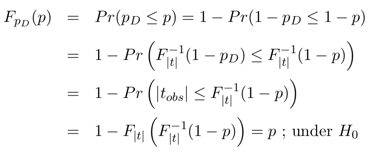

- When you have to show equations, mark the place where people need to pay attention
  - explain why it is important
  - show a trick you made to prove
  - demonstrate the equation made your data analysis possible

### Example: good slide

- View the TED [talk by H. Rosling](http://www.ted.com/talks/hans_rosling_shows_the_best_stats_you_ve_ever_seen?language=en). How excited are you when you talk?
- A plot itself may not be interesting unless you point out the feature and talk in depth

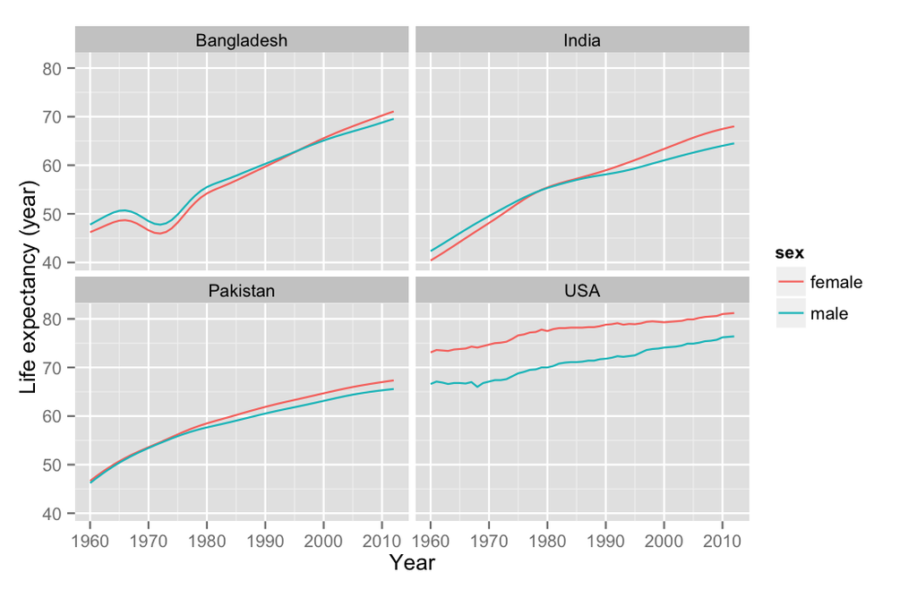

### Talk about your data

- Sources of data
  - observational
  - experimental
  - public?
- Show some interesting summary
  - tables
  - graphics
- Any anomaly in the data

### Write your speech

- Write your complete speech
  - explain bulletted points in your natural style. Don't just read them.
  - write what you intend to say on each bullet
- Be in the domain of your write-ups
  - you have only 10 minutes !
  - don't try to say anything else other than what you intended to say
  - don't try to make up instant sentences
- Use the slides as a guide only to remind you what to say in each bullet
  - bullets should not be more than a line

### Transition between slides

- Know your slides very well
  - prepare the audience about what is coming next
  - sometimes audience will be happy that the slide is exactly what they imagined
- Pay special attention to write what you will say when
  - you will leave a slide
  - at the start of a new slide

### Manage your time

- Plan how much time you will spend on certain slide
  - writing your speech will help
  - smoother transition between slides will help to implement the plan
- You don't have time to show everything
  - if you spend 1 minute in each slide, you can have only 10 slides to show
  - pick few important points you want to talk about
    - create a slide based on each point
    - create some other slides just to fill in the gaps
  - use your written report to explain little details

### Practice before your talk

- Even famous speakers practice a lot before a presentation
  - saves time
  - helps avoiding unnecessary speeches
  - can explain difficult concept in a natural way
  - makes transition between slides continuous
  - helps you not to rush

## Practice, Practice and Practice

### Reading assignment and references

- Tips for presenting your work  
  http://journal.r-project.org/archive/2011-1/RJournal_2011-1_Cook.pdf
- TED talk by H. Rosling. (2006) GapMinder talk. Notice how he displays and explains data  
  http://www.ted.com/talks/hans_rosling_shows_the_best_stats_you_ve_ever_seen?language=en